# Prediction of Interest Rate

### Study of sharp cut in residual plot

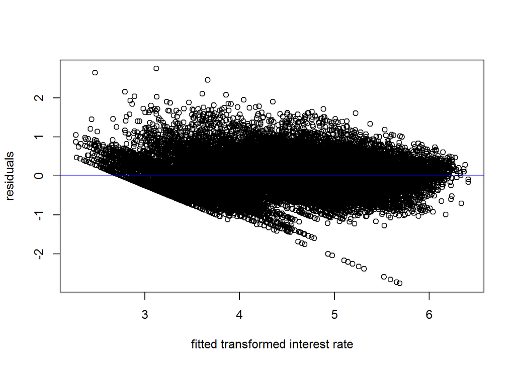

```r
plot(fitted(md3),resid(md3),xlab = "fitted transformed interest rate",ylab= "residuals")
abline(h=0,col='blue')
```

```r
# identify(fitted(md3),resid(md3))
#some example on the sharp cut line 7855  8829  8890 10304 13436 14065 18618 20885
#identify them
loandata[c(7855,8829,8890,10304,13436,14065,18618,20885),]# all have interest rate at 5.42, lowest rate
```

```
##       int_rate loan_amnt       term home_ownership annual_inc   dti
## 7855      5.42     10000  36 months       MORTGAGE      55000  9.53
## 8829      5.42     14400  36 months       MORTGAGE      60000  8.66
## 8890      5.42      6000  36 months           RENT     100000 20.83
## 10304     5.42      3500  36 months       MORTGAGE      49000  5.85
## 13436     5.42     12000  36 months           RENT      91392  8.18
## 14065     5.42      6000  36 months           RENT      50508  2.42
## 18618     5.42      4000  36 months       MORTGAGE      57600  7.25
## 20885     5.42      6475  36 months           RENT      30000  7.20
##       delinq_2yrs fico_range_low open_acc revol_util    gdp
## 7855            0            765       11        9.3 0.0364
## 8829            0            750       10       37.8 0.0364
## 8890            0            750        6       56.5 0.0364
## 10304           0            745        9       30.7 0.0364
## 13436           0            755        7       15.9 0.0364
## 14065           0            775        7       16.8 0.0364
## 18618           0            810       12        0.4 0.0364
## 20885           0            770        7       34.9 0.0364
```

```r
# other "linear trend"
loandata[c(17151,18028,18299, 18656, 19717, 20771, 21492, 21620, 24162, 24273, 24336),] #all have interest rate at 5.7
```

```
##       int_rate loan_amnt       term home_ownership annual_inc   dti
## 17151     5.79      6000  36 months           RENT      70000  3.50
## 18028     5.79      4000  36 months       MORTGAGE      40000  8.85
## 18299     5.79      5375  36 months            OWN      14400 15.17
## 18656     5.79     10600  36 months       MORTGAGE      75000 13.38
## 19717     5.79     10200  36 months           RENT      83500  8.87
## 20771     5.79      8000  36 months           RENT      51000 16.94
## 21492     5.79     11200  36 months           RENT     180000 21.77
## 21620     5.79      6000  36 months       MORTGAGE      90000 16.13
## 24162     5.79      6000  60 months       MORTGAGE      63600  4.06
## 24273     5.79      7750  60 months       MORTGAGE      45444 18.93
## 24336     5.79     11200  60 months       MORTGAGE      80000  6.63
##       delinq_2yrs fico_range_low open_acc revol_util    gdp
## 17151           0            795        4       12.8 0.0364
## 18028           0            800       13        0.0 0.0364
## 18299           0            735        9       30.5 0.0364
## 18656           0            750       11       52.9 0.0364
## 19717           0            745        7       24.7 0.0364
## 20771           0            745        7       38.6 0.0364
## 21492           0            800       17        0.8 0.0364
## 21620           0            745        9       55.4 0.0364
## 24162           0            780        6       17.0 0.0456
## 24273           0            770       10       28.5 0.0456
## 24336           0            790        6       10.7 0.0456
```

We find out these data points are caused by the lowest ineterest rate offered by the company. Also because the data is not strictly continuous, it has this step-wise like pattern.

### Influential points

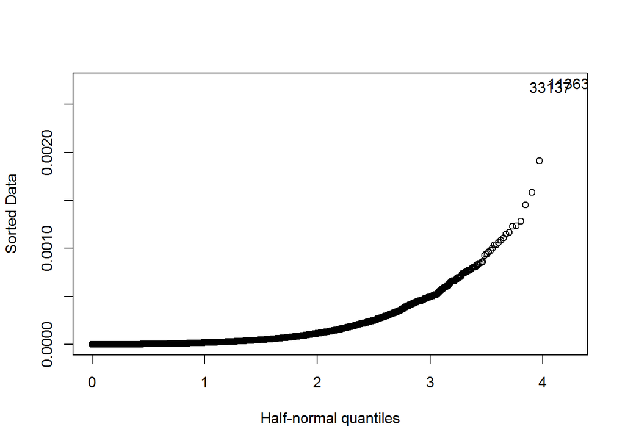

```r
halfnorm(cooks.distance(md3))
```

```r
# observation:row 11363 and row 33137
loandata[c(11363,33137),]
```

```
##       int_rate loan_amnt       term home_ownership annual_inc   dti
## 11363    15.23      1000  36 months       MORTGAGE      3e+04 23.52
## 33137    14.26      1000  36 months            OWN      1e+05  3.55
##       delinq_2yrs fico_range_low open_acc revol_util    gdp
## 11363           0            765       29        2.0 0.0364
## 33137           0            740       35        7.2 0.0456
```

The largest Cook’s distance is 0.0025,<<0.5. We don’t have any influential points. We still examine the points with largest Cook’s distance, draw those cases out. One of them is an outlier as we studied earlier.